# WebAnalytics

## Exploratory Data Analysis

**a) Administrative_Duration Column** *Mean*

```r
mean(new_data$Administrative_Duration)
```

```
## [1] 81.68214
```

The average time spent on the administrative page was 81.68 mins

**Use a histogram to visualize the distribution**

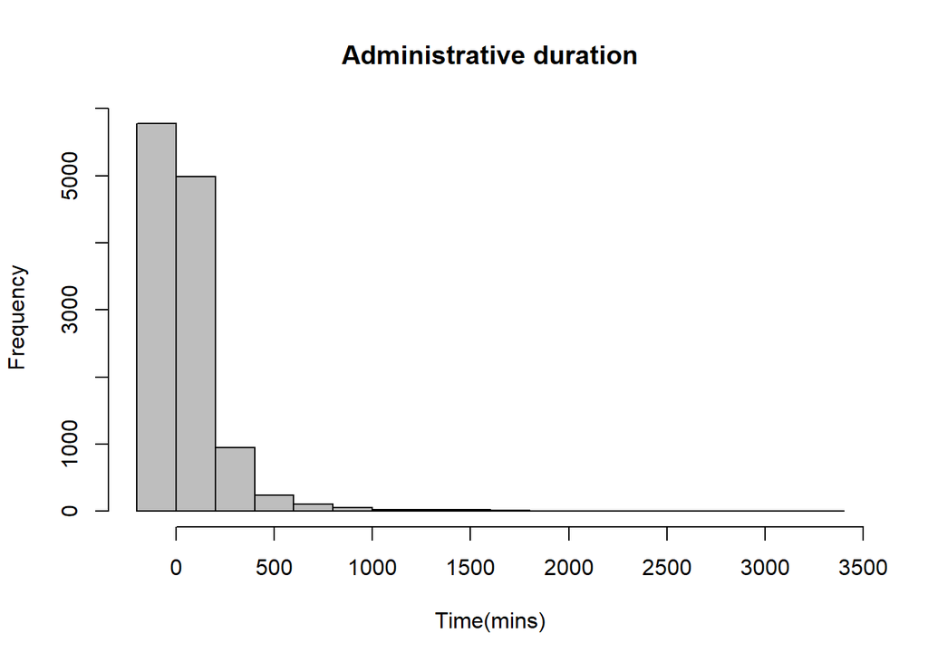

```r
hist(new_data$Administrative_Duration, main = "Administrative duration", xlab = "Time(mins)", col = "gray")
```

The above scale of the timeframe runs from 0-3500 because it is over a period of 1 month. We observe that most people did not concentrate on the administrative column hence the high frequency of zero(0) Another group of customers spent less than 500 mins per month in the administrative page with very few people spending more that 500 mins on the same page.

**b) Informational_Duration** *Mean*

```r
mean(new_data$Informational_Duration)
```

```
## [1] 34.83734
```

On average people spent 34.84 mins on the information page.

**A visualization of the Information_Duration column**

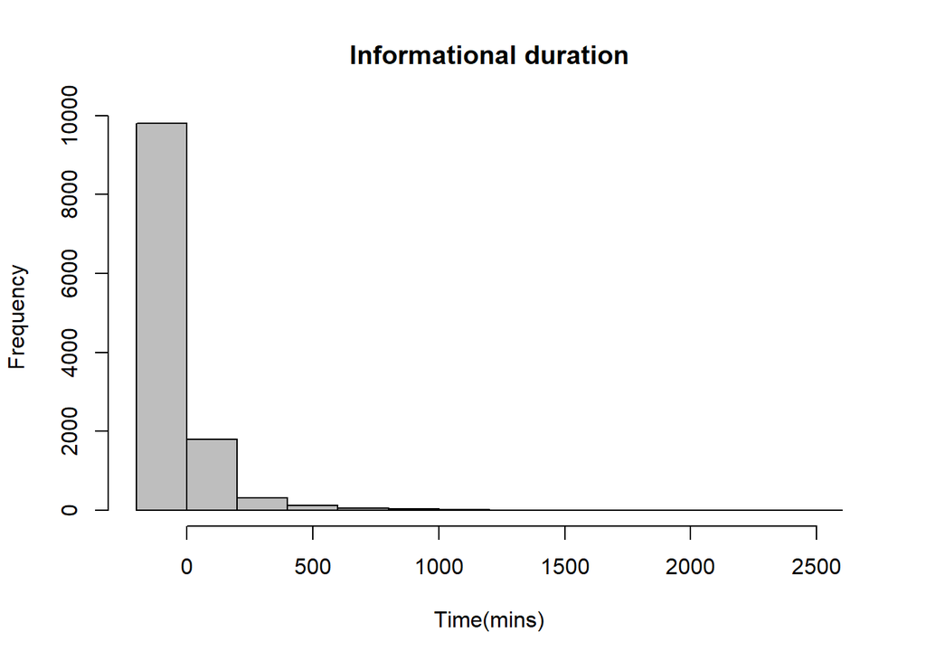

```r
hist(new_data$Informational_Duration, main = "Informational duration", xlab = "Time(mins)", col = "gray")
```

**c) ProductRelated**

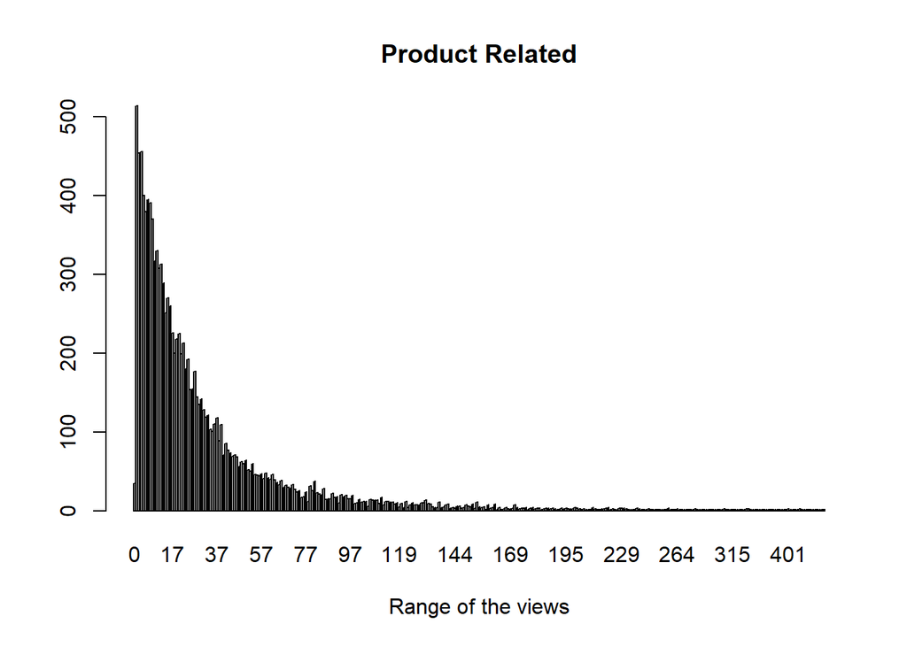

```r
Products <- new_data$ProductRelated
Products_freq <- table(Products)
barplot(Products_freq, main = "Product Related", xlab = "Range of the views")
```

The plot above shows that the views progressively reduced as you move across the graph.

**d) ProductRelated_Duration**

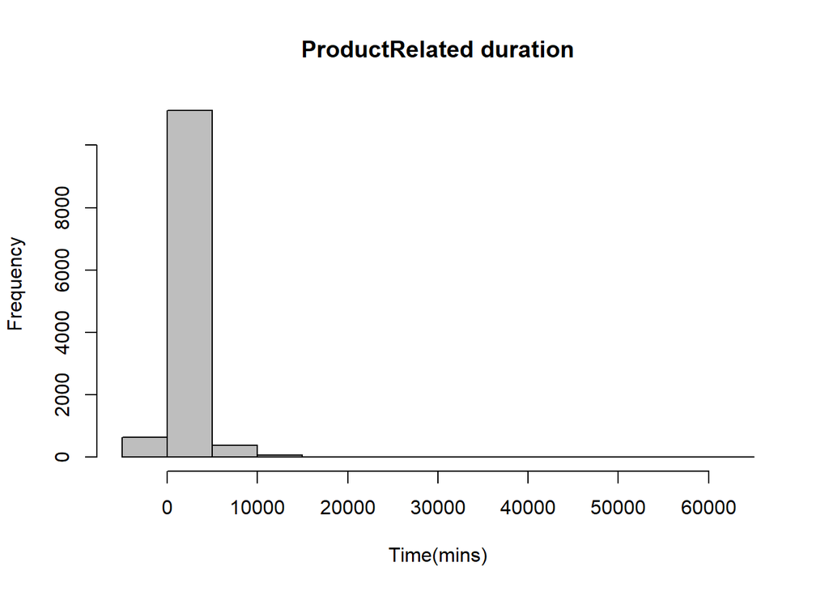

```r
hist(new_data$ProductRelated_Duration, main = "ProductRelated duration", xlab = "Time(mins)", col = "gray")
```

**e) Bounce rates column** Get the highest bounce rate

```r
max(new_data$BounceRates)
```

```
## [1] 0.2
```

The maximum bounce rate was 20%

**A visualization of the Bouncerate Column**

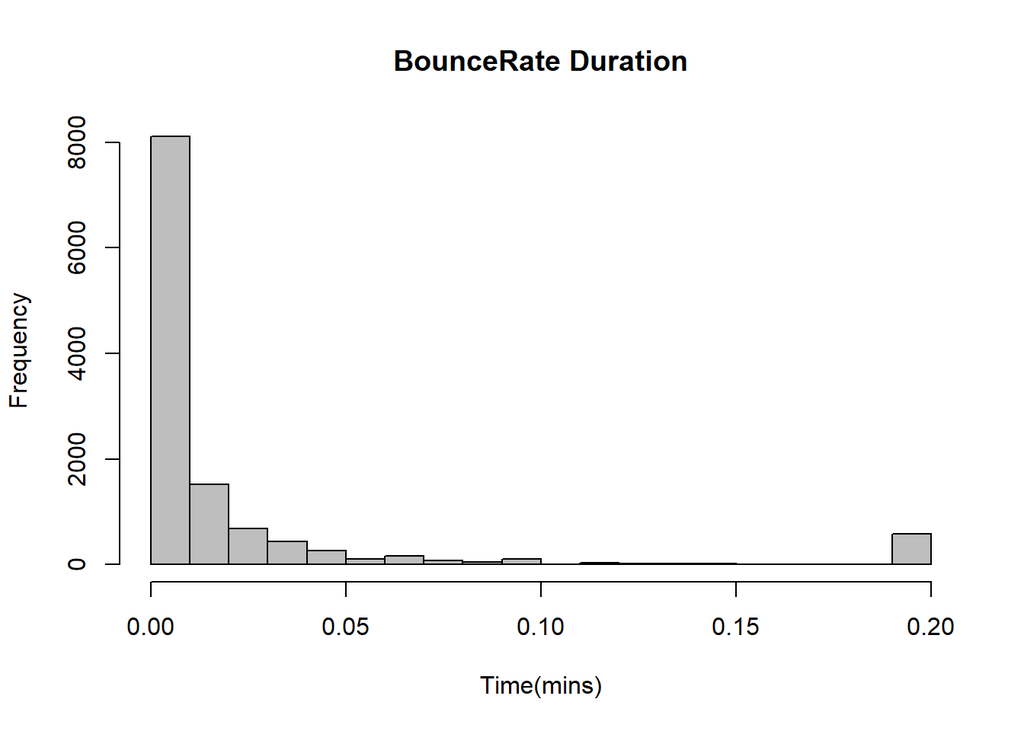

```r
hist(new_data$BounceRates, main = "BounceRate Duration", xlab = "Time(mins)", col = "gray")
```

The bounce rate of the website was distributed from 0.00 to 0.20 where the different pages had a bounce rate but not as high.

**f) ExitRates** Check for the highest exit rate

```r
max(new_data$ExitRates)
```

```
## [1] 0.2
```

A 20% exit rate was the highest

**A visualization of the Exitrates Column**

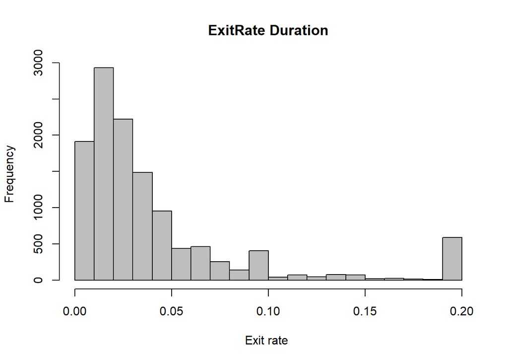

```r
hist(new_data$ExitRates, main = "ExitRate Duration", xlab = "Exit rate ", col = "gray")
```

**g)PageValues Column** *Mean*

```r
mean(new_data$PageValues)
```

```
## [1] 5.9525
```

The average page value projected was 5.95

**Plotting the distribution of the Pagevalue column**

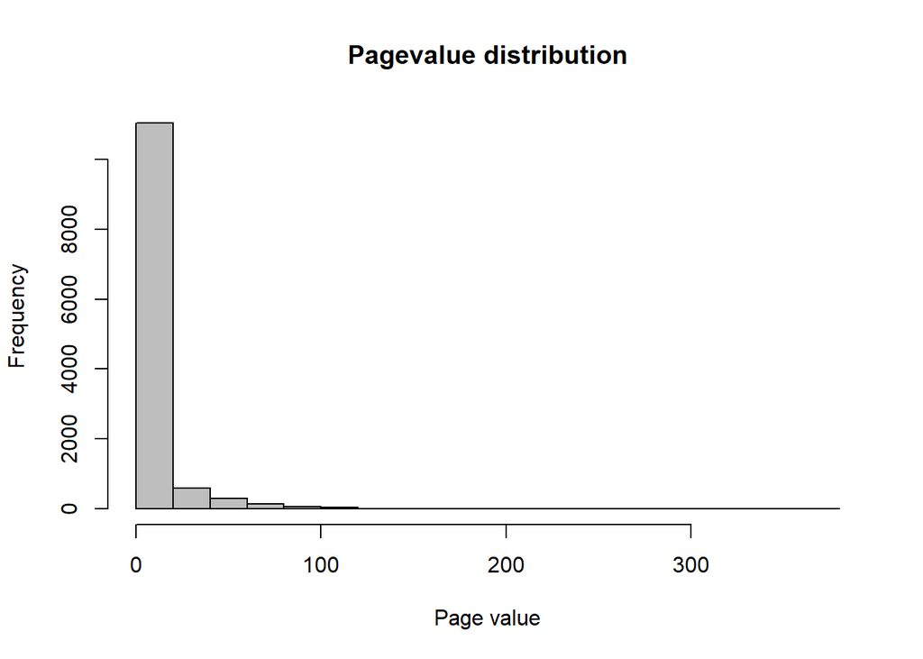

```r
hist(new_data$PageValues, main = "Pagevalue distribution", xlab = "Page value", col = "gray")
```

Page Value is how you measure the monetary performance of your web pages in Google Analytics. From the distribution above, we observe that the pave value was in a range of 0-362.

**h) SpecialDay Column**

```r
unique(new_data$SpecialDay)
```

```
## [1] 0.0 0.4 0.8 1.0 0.2 0.6
```

SpecialDay indicates the closeness of the site visiting time to a specific special day.

**A barplot to represent the distribution of the data**

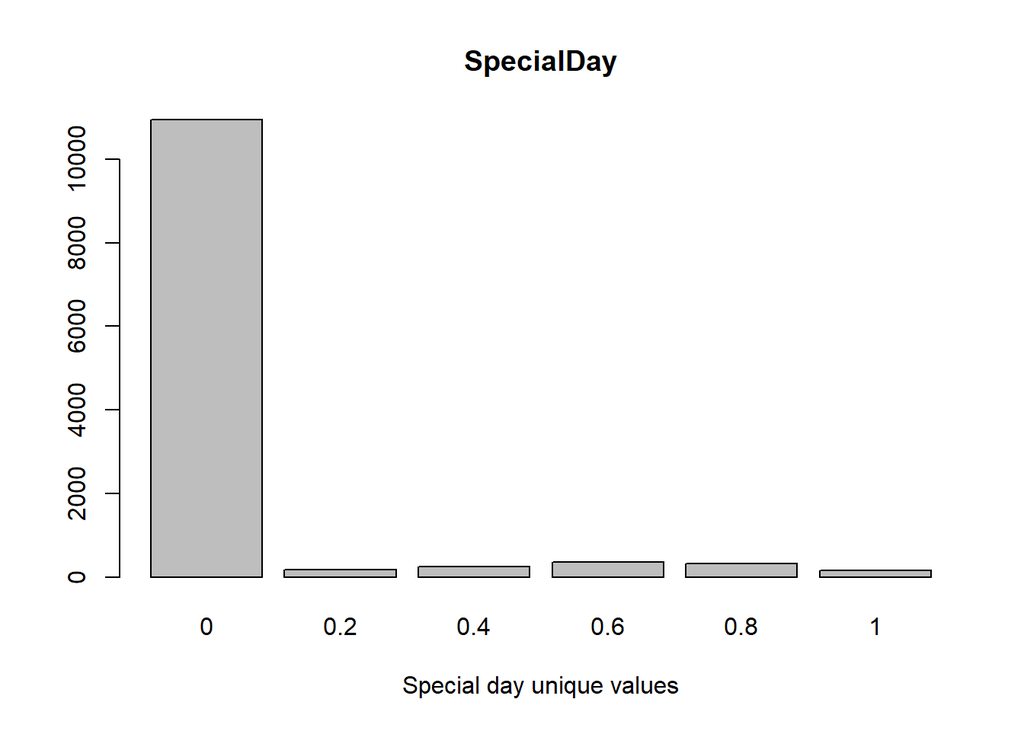

```r
specialday <- new_data$SpecialDay
special_freq <- table(specialday)
barplot(special_freq, main = "SpecialDay", xlab = "Special day unique values")
```

**i) Month Column** Get the unique values represented in the dataset

```r
unique(new_data$Month)
```

```
##  [1] Feb  Mar  May  Oct  June Jul  Aug  Nov  Sep  Dec
## Levels: Aug Dec Feb Jul June Mar May Nov Oct Sep
```

**Use a barplot to visualize**

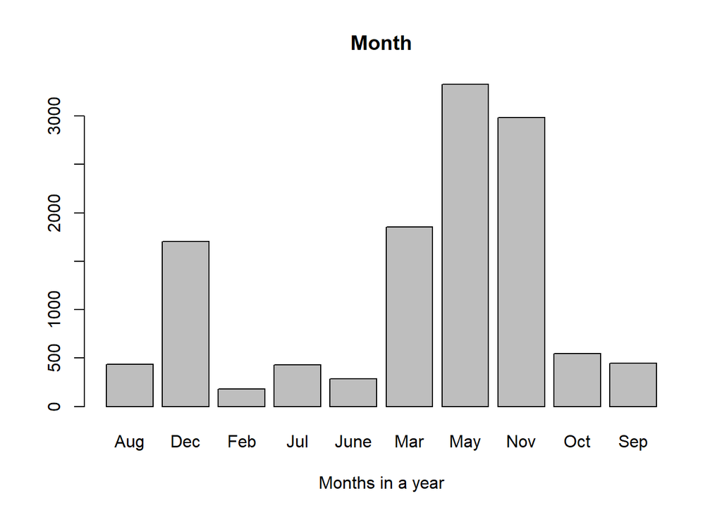

```r
months <- new_data$Month
months_freq <- table(months)
barplot(months_freq, main = "Month", xlab = "Months in a year")
```

May led the list with most visits in the website followed by November, March and December respectively. With may being psrt of the Spring season, the brand’s Sales and Marketing team should consider having more products at such a time and also have enticing brands represented. The rest of the months had few visits.

**j) Browser Column**

```r
unique(new_data$Browser)
```

```
##  [1]  1  2  3  4  5  6  7 10  8  9 12 13 11
```

There were 13 different browsers represented in the data

**Use a barplot to visualize**

[figure not shown]

```r
browsers <- new_data$Browser
browsers_freq <- table(browsers)
barplot(browsers_freq, main = "Month", xlab = "Special day unique values")
```

**k) Region Column**

```r
unique(new_data$Region)
```

```
## [1] 1 9 2 3 4 5 6 7 8
```

From the dataset provided, the website visitors were from 9 different regions

**Use a barplot to visualize**

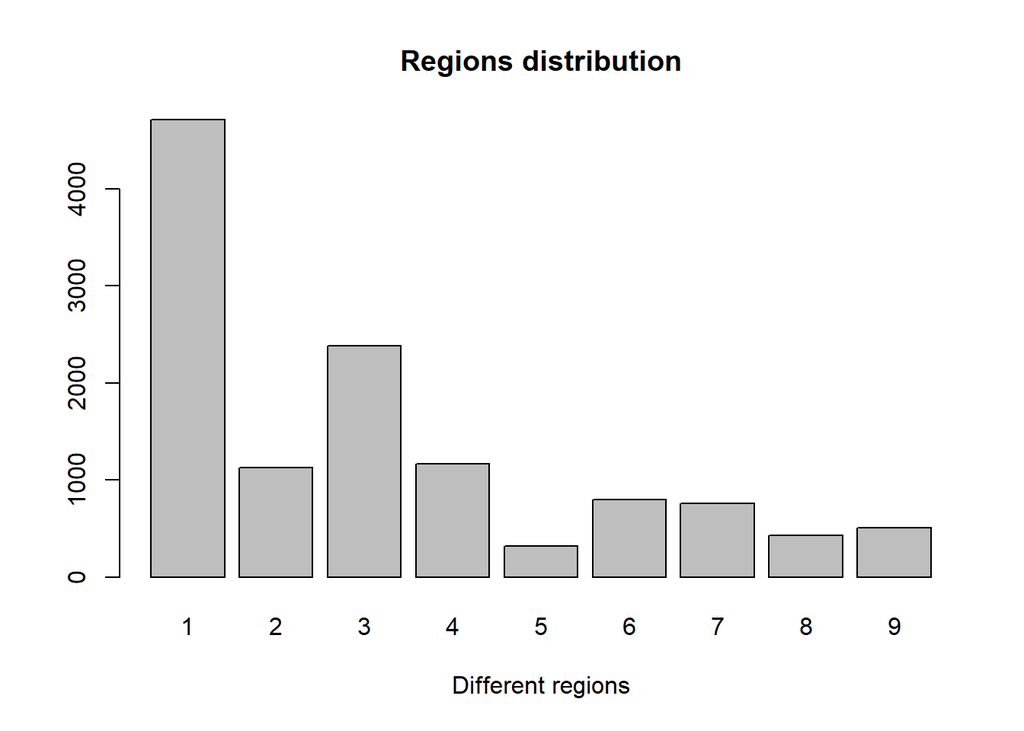

```r
regions <- new_data$Region
region_freq <- table(regions)
barplot(region_freq, main = "Regions distribution", xlab = "Different regions")
```

Most website visitors over 4000 were from region 1 followed by region 3 with a balance observed in regions 2 and 4. Regions 5-9 had less than 1000 people visit the website.

**l) TrafficType Column**

```r
unique(new_data$TrafficType)
```

```
##  [1]  1  2  3  4  5  6  7  8  9 10 11 12 13 14 15 18 19 16 17 20
```

A traffic type is a particular identifier type for any hierarchy of your customer base. Traffic types in Split are completely customizable and can be any database key you choose to send to Split hence the range of 1-20

**Use a barplot to visualize**

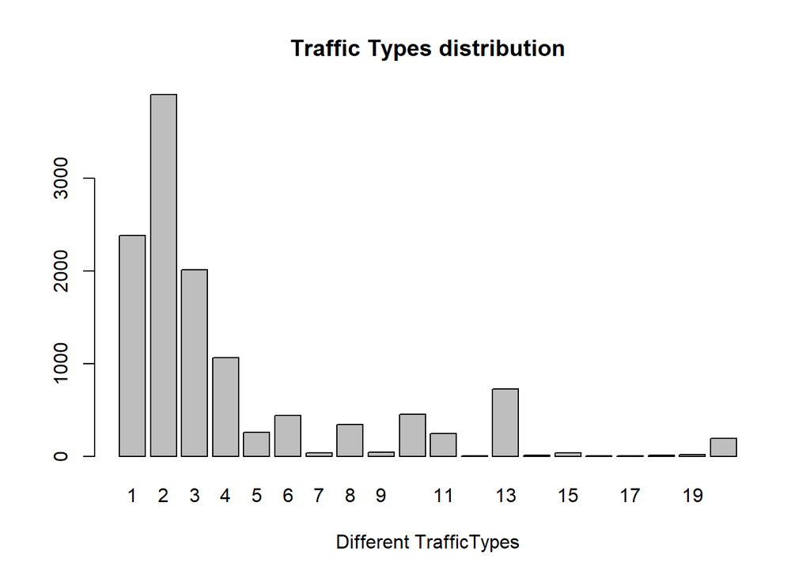

```r
Traffictype <- new_data$TrafficType
traffictypes_freq <- table(Traffictype )
barplot(traffictypes_freq, main = "Traffic Types distribution", xlab = "Different TrafficTypes")
```

Traffic type 2 division had most visitors under it followed by type 1,3,and 4 respectively.

**m) VisitorType Column**

```r
unique(new_data$VisitorType)
```

```
## [1] Returning_Visitor New_Visitor       Other
## Levels: New_Visitor Other Returning_Visitor
```

There were 3 unique classes of visitors. New Visitors are those navigating to your site for the first time on a specific device while Returning Visitors have visited your site before and are back for more.

**Use a barplot to visualize**

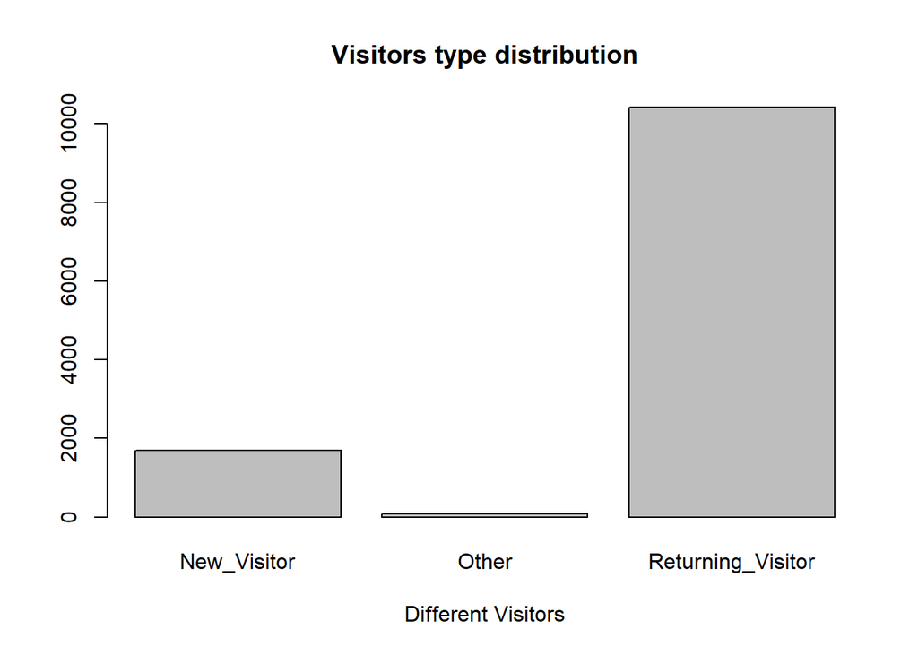

```r
Visitors <- new_data$VisitorType
visitorstypes_freq <- table(Visitors)
barplot(visitorstypes_freq, main = "Visitors type distribution", xlab = "Different Visitors")
```

Over 10,000 peope were returning visitors which is a good thing for the company showing the effectiveness of the inbound digital marketing techniques across the web. The company should purpose to improve the number of new visitors either by offering better products with better prices to improve their sales.

**n) Weekend Column**

```r
unique(new_data$Weekend)
```

```
## [1] FALSE  TRUE
```

This shows that the visits to the website was either during weekends or otherdays. **Use a barplot to visualize**

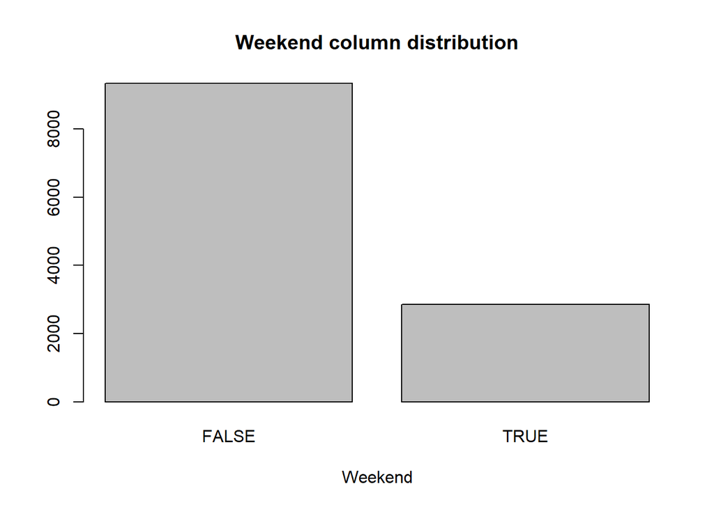

```r
weekends <- new_data$Weekend
weekend_freq <- table(weekends)
barplot(weekend_freq, main = "Weekend column distribution", xlab = "Weekend")
```

Most visits to the website happened off weekends according to the visulaization above. About 3,000 people visisted the site over the weekend.

**O) Revenue Column**

```r
unique(new_data$Revenue)
```

```
## [1] FALSE  TRUE
```

This shows that a page either mad revenue or not

**Use a barplot to visualize**

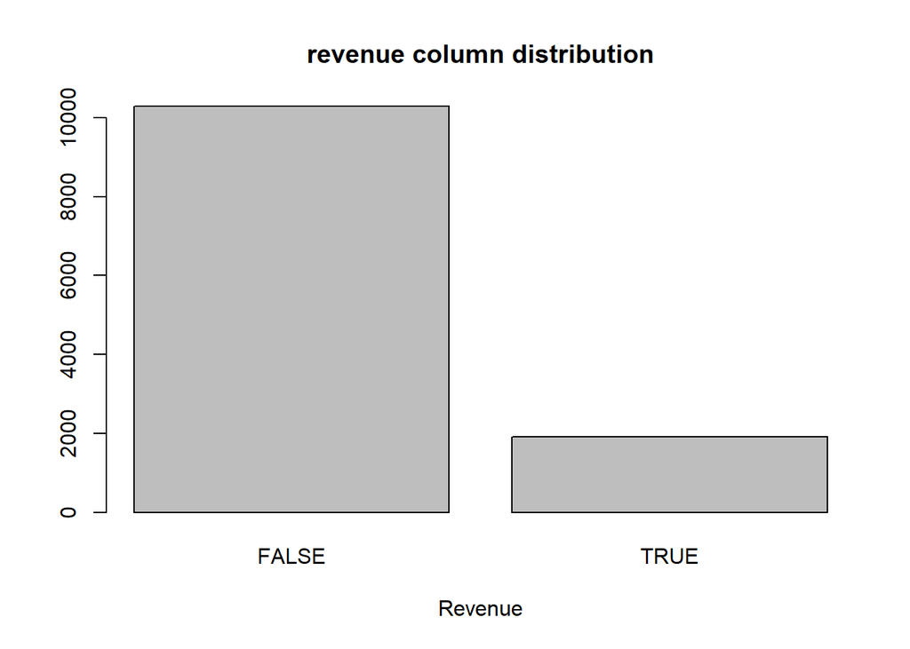

```r
revenue <- new_data$Revenue
revenue_freq <- table(revenue)
barplot(revenue_freq, main = "revenue column distribution", xlab = "Revenue")
```

Most visits did not go to the point of making reveunue in accordance to the above visualization. About 2000 visits to the different pages made money for the company.

## Bivariate Analysis

**Get an overview of the correlation between the numerical variables**

```r
cov(new_data[,-c(0,2,4,10,11,12,13,14,15,16,17)])
```

```
##                         Administrative Informational ProductRelated
## Administrative             11.09456996   1.594806280     63.6117036
## Informational               1.59480628   1.627709681     21.2021821
## ProductRelated             63.61170357  21.202182071   1989.2412959
## ProductRelated_Duration  2372.71642208 945.703033133  73668.6330189
## BounceRates                -0.03231259  -0.006343127     -0.3918681
## ExitRates                  -0.04794942  -0.009414909     -0.5902590
## PageValues                  6.02328225   1.128072018     45.0324519
## Revenue                     0.16479971   0.043383040      2.5264373
##                         ProductRelated_Duration   BounceRates
## Administrative                       2372.71642  -0.032312588
## Informational                         945.70303  -0.006343127
## ProductRelated                      73668.63302  -0.391868084
## ProductRelated_Duration           3686121.49674 -15.200227238
## BounceRates                           -15.20023   0.002061387
## ExitRates                             -21.78350   0.001896814
## PageValues                           1821.19283  -0.098258013
## Revenue                               104.59767  -0.002397839
##                             ExitRates    PageValues       Revenue
## Administrative           -0.047949418    6.02328225   0.164799707
## Informational            -0.009414909    1.12807202   0.043383040
## ProductRelated           -0.590258984   45.03245187   2.526437312
## ProductRelated_Duration -21.783499809 1821.19282970 104.597665309
## BounceRates               0.001896814   -0.09825801  -0.002397839
## ExitRates                 0.002138800   -0.14976966  -0.003432087
## PageValues               -0.149769655  348.11318376   3.333606363
## Revenue                  -0.003432087    3.33360636   0.131954161
```

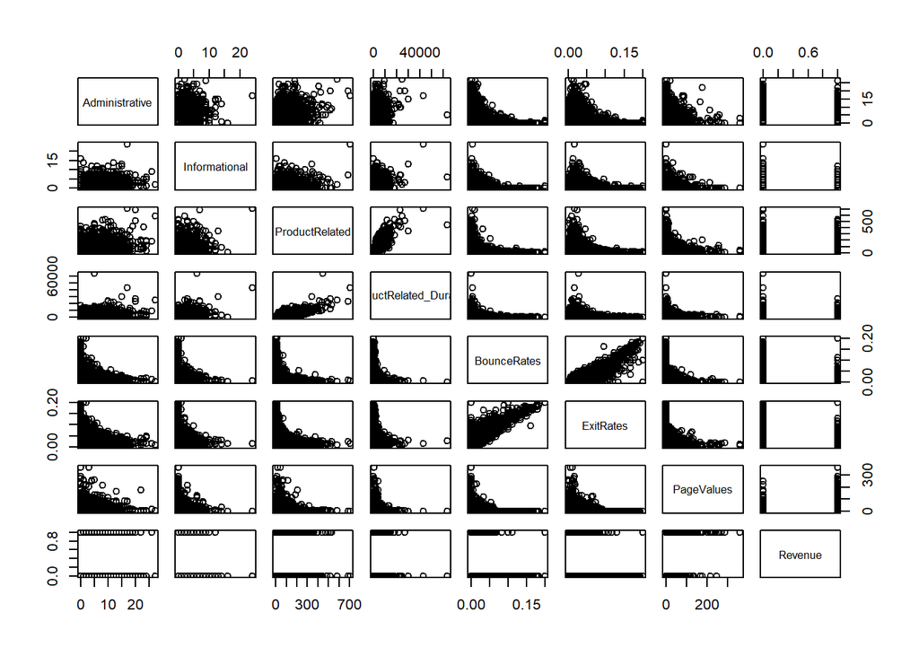

```r
pairs(new_data[,-c(0,2,4,10,11,12,13,14,15,16,17)])
```

A plot of the correlation coeffients matrix visualizes the same above. There is a positive correlation between bounce rates Vs exit rates and ProductRelated Vs Product_duration.

**Administrative Vs BounceRates**

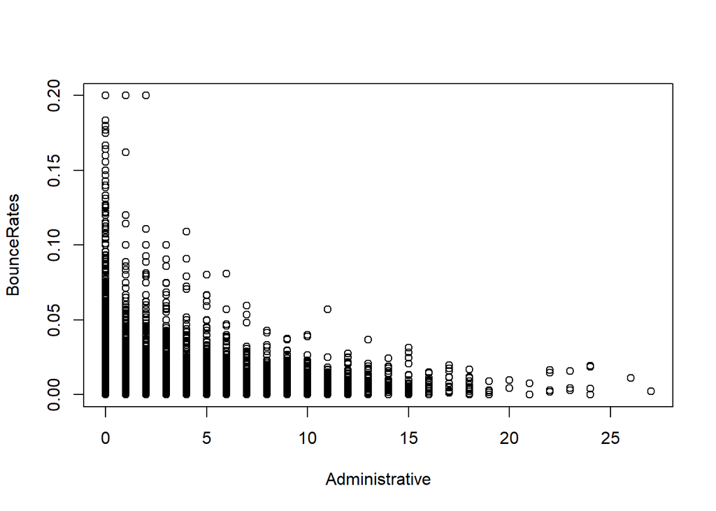

```r
attach(new_data)
plot(Administrative, BounceRates)
```

There is a negative correlation between the 2 variables as shown above. As the independent variable(Administrative) increases, the dependent variable(bounce rates) decreases. Increase in the independent variable means increase in the number of views which means a visitor is likely to move to another page in the website which will reduce the bounce rate respectively.

**Informational Vs BounceRates**

```r
attach(new_data)
```

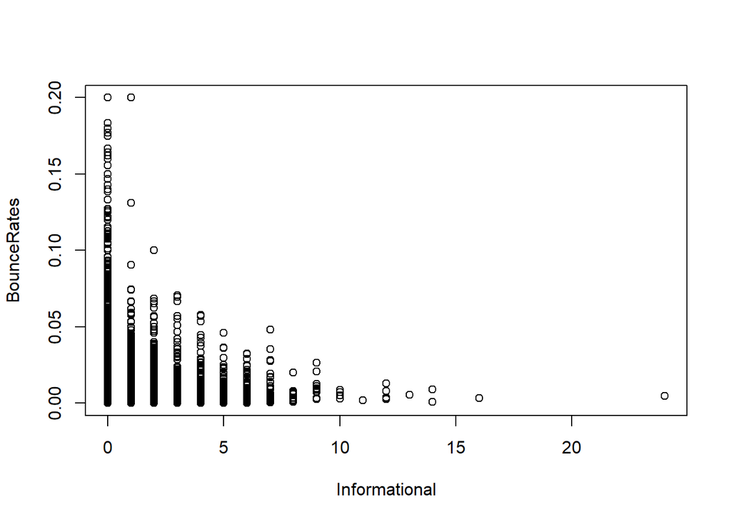

```r
plot(Informational , BounceRates)
```

There is a negative correlation between the 2 variables which is a good thing for the company in that increase in the Informational column would mean that clients have more intrest about what the company offers leading to naviagtion to another pages hence reducing the bounce rate.

**ProductRelated Vs BounceRates**

```r
attach(new_data)
```

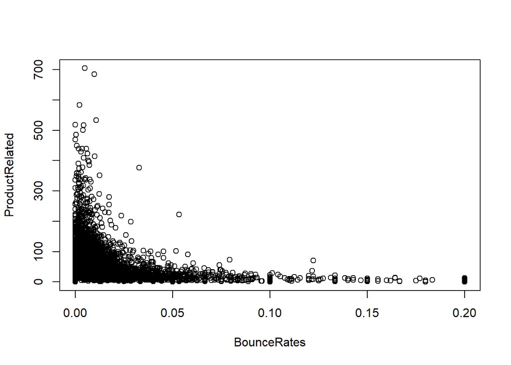

```r
plot(BounceRates, ProductRelated )
```

As the product related pages got more views, the bouncerate reduced significantly as seen in the above graph.

**Exitrates Vs Bouncerates**

```r
attach(new_data)
```

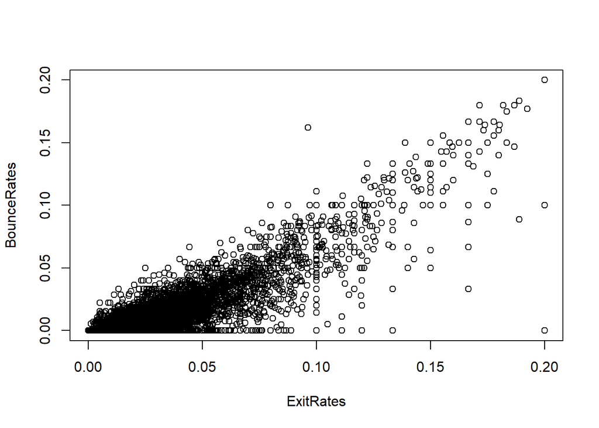

```r
plot(ExitRates , BounceRates)
```

Bounce Rate: the percentage of single-engagement sessions Exit Rate: the percentage of exits on a page There is a positive linear relationship between the 2 variables. The company should purpose to keep such rates low.

```r
attach(new_data)
```

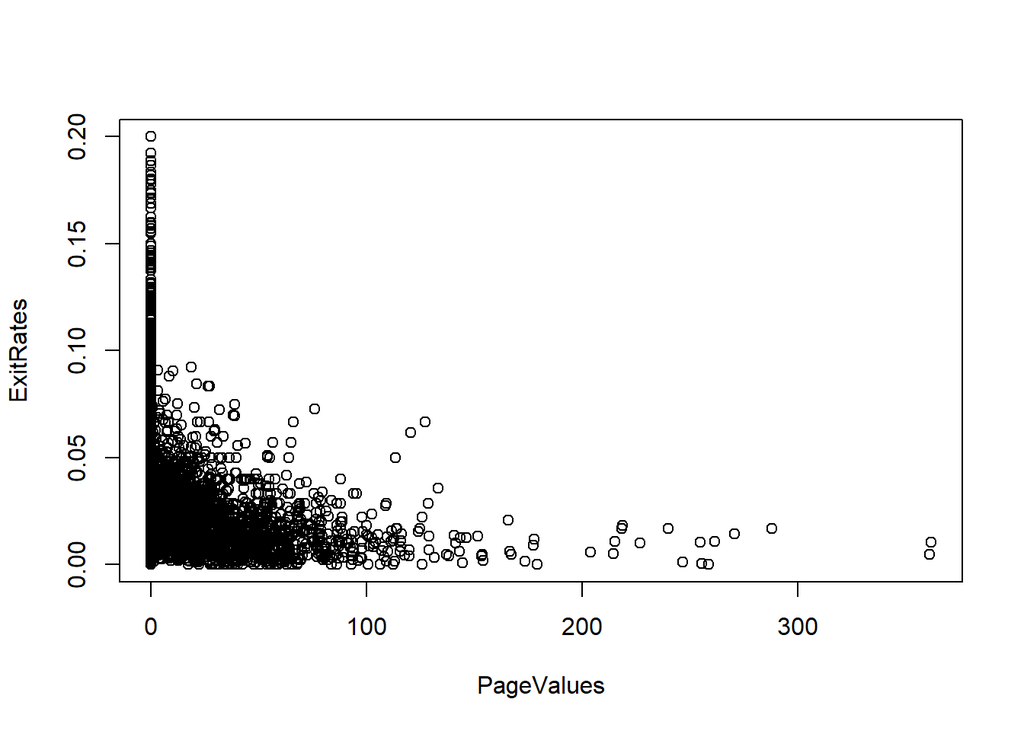

```r
plot(PageValues , ExitRates)
```

There is a negative relationship between the 2 variables in that an increase in one variables affects the other variable negatively. Exit Rate is the percentage of exits on a page. This means that increase in the exit rate affects the pagevalue negatively in that it affects the monetary peformance of the different pages.